# HW12: Dates

Ryan McAnulty

30 July 2020

## Loading required libraries

```r
library(tidyverse)
library(here)
library(lubridate)
```

## Sourcing my_functions

```r
source(here("scripts", "my_functions.R"))
```

#### Part 1: Play Date

## Inserting date code chunk

```r
birth_date <- "12/06/1984"

# Elizabeth Garret Anderson was the first female physician
anderson <- "9 June 1836"

# Mary Anning discovered the first complete Plesiosaur fossil,
# and other important Jurassic fossils
anning <-  "1799/05/21"

# Alice Augusta Ball was a chemist who developed the# first injectable treatment for leprosy.
ball <- "July 24, 1892"

# Sylvia Earle was the first chieft scientist at NOAA
earle <- "August, 30 (1935)"

# Rosalind Franklin used x-ray diffraction to# discover DNA structure. Watson and Crick claimed credit.
franklin <- "25th of July, 1920"

# Ester Lederberg was the first to discover that viruses
# infect bacteria. Led to discovery of lambda bacteriophage
lederberg <- "December 18, 1922"

# Barbara McClintock discovered transposable elements (jumping genes),
# and developed staining techniques to study chromosomes
mcclintock <- "16061902"

# Let's also remember a dream
mlk_birth <- "1/15/29"
mlk_dream <- "1963 August 28"
```

## Question 1 Convert each date to POSIXct format, usinglubridatefunctions, saving each to a unique variable.Print each result.

```r
(birth_date_po <- mdy(birth_date))
```

```
[1] "1984-12-06"
```

```r
(anderson_po <- dmy(anderson))
```

```
[1] "1836-06-09"
```

```r
(anning_po <- ymd(anning))
```

```
[1] "1799-05-21"
```

```r
(ball_po <- mdy(ball))
```

```
[1] "1892-07-24"
```

```r
(earle_po <- mdy(earle))
```

```
[1] "1935-08-30"
```

```r
(franklin_po <- dmy(franklin))
```

```
[1] "1920-07-25"
```

```r
(lederberg_po <- mdy(lederberg))
```

```
[1] "1922-12-18"
```

```r
(mcclintock_po <- dmy(mcclintock))
```

```
[1] "1902-06-16"
```

```r
(mlk_birth_po <- dmy(mlk_birth))
```

```
All formats failed to parse. No formats found.
```

```
[1] NA
```

```r
(mlk_dream_po <- ymd(mlk_dream))
```

```
[1] "1963-08-28"
```

## Question 2 Check yours dates to be sure they are correct. If you spot any errors, correct them now using the properlubridatefunction(s).

```r
(mlk_birth_po_fix <-        # Fixing the mlk_birth date using make_date
   make_date(year = 1929,
             month = 01,
             day = 15))
```

```
[1] "1929-01-15"
```

## Question 3 What day of the week were you born on? Show the full day name, not the abbreviated name or the daynumber.

```r
weekdays(birth_date_po)
```

```
[1] "Thursday"
```

## Question 4 What day of the week will your birthday be on this year? Use lubridate’s update function. You must figure out how to do it entirely by code for full points (no hard-coding). In other words, your code should work just as well next year or five years in the future, without editing.

```r
birth_date_po %>%
  update(year = year(now())) %>% # Extracting the year from the now function to use with weekdays function
  weekdays()
```

```
[1] "Sunday"
```

## Question 5 What day of the week would your birthday be on in the Year 2525, if Man is still alive? How old would you be? Here you may hard-code 2525. Show the abbreviated day of the week.

```r
birth_date_po %>%
  update(year = 2525) %>%         # Hardcoding 2525
  weekdays(abbreviate = TRUE)     # Setting to abbreviate weekday
```

```
[1] "Thu"
```

```r
Age = 2525 - year(birth_date_po)  # Calculating age from 2525
Age                               # Displaying age in that year
```

```
[1] 541
```

## Question 6 How many days was it between the birth of Dr. Elizabeth Garrett Anderson and Alice Augusta Ball?

```r
Days_ball_anderson <- ball_po - anderson_po
Days_ball_anderson
```

```
Time difference of 20499 days
```

## Question 7 What is the duration between Martin Luther King Jr.’s birth date and hisI Had a Dream speech?

```r
Days_mlk <- mlk_dream_po - mlk_birth_po_fix
as.duration(Days_mlk)
```

```
[1] "1092355200s (~34.61 years)"
```

## Question 8

```r
dates <- c(anderson_po,                   # Setting birth dates as a vector
           anning_po,
           ball_po,
           earle_po,
           franklin_po,
           lederberg_po,
           mcclintock_po,
           birth_date_po)
names(dates) <- c("Anderson",             # naming each birth date
                 "Anning",
                 "Ball",
                 "Earle",
                 "Franklin",
                 "Lederberg",
                 "McClintock",
                 "McAnulty")
dates[leap_year(dates)] %>%               # Displaying leap years
  year()
```

```
Anderson     Ball Franklin McAnulty
    1836     1892     1920     1984
```

```r
days_since = birth_date_po - dates        # Calculating days between my birthdate and the female scientists

sort(desc(days_since))                    # Listing days since
```

```
[1] -67769 -54236 -33737 -30124 -23510 -22634 -17996      0
```

#### Part 2: Wrangling and plotting with dates

#### Part 2: Wrangling and Plotting with Dates

## Lake Ice Data od ice cover from Lake Mendota from the 1852-53 to 2012-13 season

```r
lake_ice <-                                   # Naming Lake_ice.csv
  read_csv(here("data",                       # Importing lake_ice.csv
                "lake_ice.csv"),
           na = c("-999"))                    # Setting what NA is in the data
lake_ice_wrangled <-
  lake_ice %>%
  filter(lakename == "LAKE MENDOTA") %>%      # Displaying data only from from site Lake Mendota
  select(iceon_year:iceoff_day) %>%           # Displaying only dates with ice on and ice off data
  mutate(
    ice_on = make_date(iceon_year,            # Making a column of when ice appeared on the lake
                       iceon_month,
                       iceon_day),
    ice_off = make_date(iceoff_year,          # Making a column of when completely melted off of the lake
                        iceoff_month,
                        iceoff_day),
    duration = as.numeric(ice_off - ice_on)   # Making a column of how long in DAYS ice was on the lake
  )
```

## Plot of Lake Mendota ice cover from 1852-53 to 2012-13 season

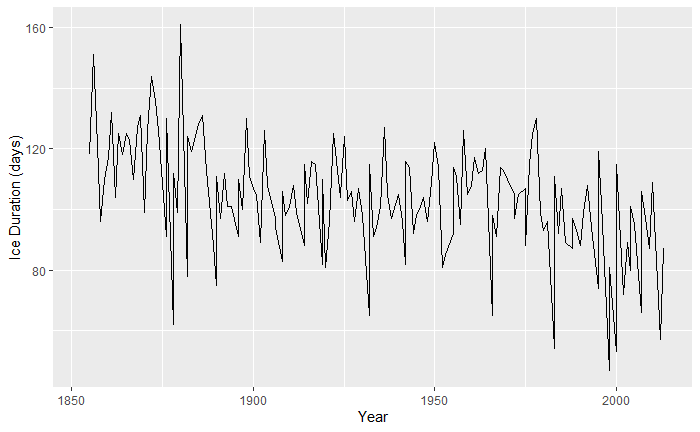

```r
lake_ice_wrangled %>%                 # Using lake_ice data for plot
  ggplot(mapping = aes(
    x = iceon_year,          # Setting x and y axes
    y = duration)) +
  geom_line(na.rm = TRUE) +  # removing NAs
  labs(x = "Year",           # Renaming axes to something more understandable
       y = "Ice Duration (days)")
```

It’s obvious that there has been less ice coverage (duration) on this lake over the last 150 + years. This could be used as evidence of global warming.

#### Soil Carbon Dioxide

```r
soil_co2 <- read_tsv(     # Naming soil co2 data
  here("data",            # Importing soil co2 data
       "soil_co2.txt"))
```

## Setting POSIXct date for 01 January 2006

```r
soil_date <- dmy("01 January 2006")
```

## Wrangling data

```r
soil_co2_wrangled <- soil_co2 %>%
  rename(
    "Day" = "DayN[]",           # Making column names syntactic
    "Datacode" = "Datecode[]",
    "Min" = "Min[]",
    "Veg" = "Veg[]",
    "Plot" = "Plot[]",
    "Group" = "Group[]",
    "Corr_Co2" = "CorrCO2[]",
    "SoilT" = "SoilT[]") %>%
  mutate(
    Date = soil_date + Day,     # Making a Date, Year, and Month column
    Year = year(Date),
    Month = month(Date,
                  label = TRUE)
)
soil_co2_year_month <-          # Making a group by Year and Month
  group_by(soil_co2_wrangled,
           Year,
           Month
)
```

## Summarizing data

```r
soil_co2_sum <-                             # Naming soil summary
  soil_co2_year_month %>%
  summarise(
    mean_Co2 = mean(Corr_Co2,               # Summarizing by mean of Co2
                    na.rm = TRUE),
    std_err_Co2 = std_err(Corr_Co2,         # Summarizing by std_err of Co2
                          na.rm = TRUE),
    .groups = "drop"                        # Dropping grouping
  )
```

## Error plot of data

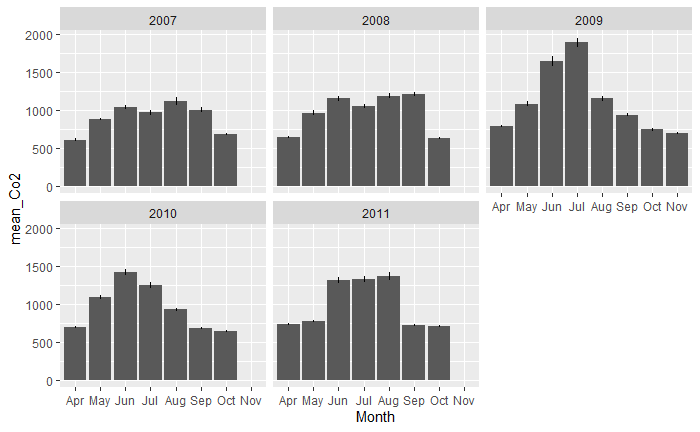

```r
soil_co2_sum %>%
  ggplot(mapping = aes(x = Month,                  # Setting x and y axes
                       y = mean_Co2)) +
  geom_col() +                                     # Making a bar graph of data
  geom_linerange(aes(ymin =                        # Setting y min at 1 std
                       mean_Co2 - std_err_Co2,
                     ymax =                        # Setting y max at 1 std
                       mean_Co2 + std_err_Co2)) +
  facet_wrap( ~ Year)                              # seperating into multiple plots by year
```

## Error plot with points same as above, just as a scatter plot

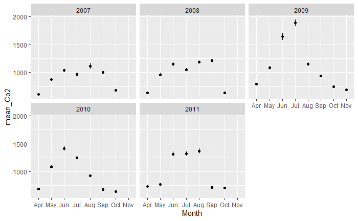

```r
soil_co2_sum %>%
  ggplot(mapping = aes(x = Month,
                       y = mean_Co2)) +
  geom_point() +
  geom_linerange(aes(ymin =
                       mean_Co2 - std_err_Co2,
                     ymax = mean_Co2 + std_err_Co2)) +
  facet_wrap(~Year)
```

Something happened in 2009 to get such high numbers, it woud be interesting to see what happened.

#### Mississippi River Discharge

## Importing and wrangling data

```r
river_thebes <-
  read_csv(here("data",
                "thebes_discharge.csv"))
river_thebes_tidy <-
  river_thebes %>%
  pivot_longer("1988":"2018",
               names_to = "Year",
               values_to = "Discharge") %>%
  mutate(Discharge = Discharge/1000) %>%
  group_by(Year, Month)
```

```r
river_sum <-
  river_thebes_tidy %>%
  summarise(mean_Discharge =
              mean(Discharge,
                   na.rm = TRUE),
            .groups = "drop") %>%
  mutate(
    Event = case_when(
      Year == 1993 |
        Year == 2011 ~ "Flood",
      Year == 1988 |
        Year == 2012 ~ "Drought",
      TRUE ~ "Normal")
)
```

# Creating smaller data set for these “Event” years

```r
river_event <- river_sum %>%
  filter(Year %in% c(1988,
                     1993,
                     2011,
                     2012))
river_event
```

| Year | Month | mean_Discharge | Event |
| --- | --- | --- | --- |
| 1988 | 1 | 189.38710 | Drought |
| 1988 | 2 | 211.20690 | Drought |
| 1988 | 3 | 211.19355 | Drought |
| 1988 | 4 | 266.76667 | Drought |
| 1988 | 5 | 140.06452 | Drought |
| 1988 | 6 | 83.85667 | Drought |
| 1988 | 7 | 73.60000 | Drought |
| 1988 | 8 | 71.63871 | Drought |
| 1988 | 9 | 75.86000 | Drought |
| 1988 | 10 | 76.96452 | Drought |

[output cut: 38 more lines]

# Plotting river_sum data as Month vs. mean_Discharge

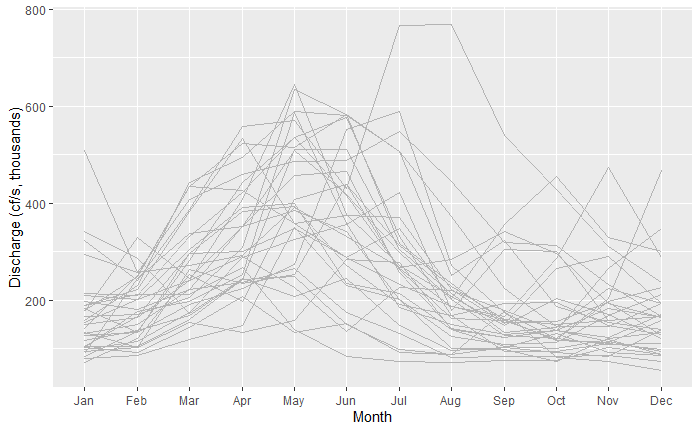

```r
p1 <- river_sum %>%                          # Naming this plot p1
  mutate(Month = month(Month,                # Mutating Month to display as abbreviated characters
                       label = TRUE)) %>%
  ggplot(mapping = aes(x = Month,            # Setting axes
                       y = mean_Discharge,
                       group = Year)) +      # Grouping months by year
    geom_line(aes(),color = "gray70",        # Plotting as a line plot, Setting color as gray70 at size 0.3
              size = 0.3) +
    labs(y = "Discharge (cf/s, thousands)"   # Renaming labels
)
p1
```

# Adding in Event data set by layers

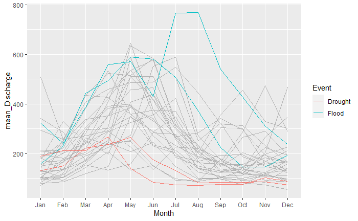

```r
river_sum %>%                                # First part is the same as above
  mutate(Month =
           month(Month,
                 label = TRUE)) %>%
  ggplot(mapping = aes(x = Month,
                       y = mean_Discharge,
                       group = Year)) +
  geom_line(aes(),
            color = "gray70",
            size = 0.3) +
  geom_line(river_event,                     # Changing data set to river_event
            mapping = aes(color = Event))    # Changing color aes to correspond with the Events
```